# AAL Q4 2020 Sales Analysis

Exploration of Australia-wide Q4 2020 apparel sales to highlight high/low performing states, demographic groups, and time-of-day patterns. Visuals and recommendations target the Sales & Marketing head for next-quarter planning.

## Problem Statement Coverage

- Q1: Setup & basic loading (shape/info/head).
- Q2: Data wrangling (missing/incorrect, cleaning).
- Q3: Normalization (Min-Max).
- Q4: GroupBy insights (state totals, state x group, state x time).
- Q5: Identify top/low revenue states.
- Q6: Demographic group-wise sales across states.
- Q7: Time-of-day peak/off-peak analysis.
- Q8: Daily/Weekly/Monthly/Quarterly charts.
- Q9: Box plot for descriptive stats.
- Q10: Seaborn distribution plot. Each section below is labeled with its question.

## Objectives

- Find the states generating the highest revenue.
- Spot under-performing states that need tailored sales programs.
- Compare demographic group performance (Kids, Women, Men, Seniors) across states.
- Identify peak/off-peak times of day to support hyper-personalization and next-best-offer programs.
- Provide daily/weekly/monthly/quarterly trend charts plus descriptive statistics and distribution views.
- Conclude with clear recommendations and a rationale for the visualization choices.

## Problem Statement Coverage

```python
import warnings
warnings.simplefilter("ignore", category=FutureWarning)
import pandas as pd
import seaborn as sns
import matplotlib.pyplot as plt
from pathlib import Path

pd.set_option('display.float_format', lambda x: f"{x:,.0f}")
sns.set_theme(style="whitegrid", palette="deep")

# Resolve data path whether notebook is run from project root or this folder
try:
    base = Path(__file__).parent
except NameError:
    base = Path.cwd()

candidates = [
    base / 'AusApparalSales4thQrt2020.csv',
    base / 'Project' / 'Sales_Analysis' / 'AusApparalSales4thQrt2020.csv',
    base / 'Applied_data_science_with_python' / 'Project' / 'Sales_Analysis' / 'AusApparalSales4thQrt2020.csv'
]
DATA_PATH = next((p for p in candidates if p.exists()), None)
if DATA_PATH is None:
    raise FileNotFoundError('AusApparalSales4thQrt2020.csv not found; please update DATA_PATH.')
```

### Q1: Setup and Basic Loading

Shape, info, and first rows of the dataset.

```python
# Load and clean
raw = pd.read_csv(DATA_PATH)
df = raw.copy()
# Strip stray spaces in categorical columns
df['State'] = df['State'].str.strip()
df['Group'] = df['Group'].str.strip()
df['Time'] = df['Time'].str.strip()
# Parse dates and create time features
df['Date'] = pd.to_datetime(df['Date'].str.strip(), format="%d-%b-%Y")
df['Month'] = df['Date'].dt.to_period('M').dt.to_timestamp()
df['Week'] = df['Date'].dt.to_period('W').dt.start_time
df['Quarter'] = df['Date'].dt.to_period('Q').dt.start_time
# Order time-of-day categories
TIME_ORDER = ["Morning", "Afternoon", "Evening"]
df['Time'] = pd.Categorical(df['Time'], categories=TIME_ORDER, ordered=True)

print(df.head())
print("\nRows:", len(df))
print("\nMissing values by column:\n", df.isna().sum())
```

```
        Date       Time State    Group  Unit  Sales      Month       Week  \
0 2020-10-01    Morning    WA     Kids     8  20000 2020-10-01 2020-09-28
1 2020-10-01    Morning    WA      Men     8  20000 2020-10-01 2020-09-28
2 2020-10-01    Morning    WA    Women     4  10000 2020-10-01 2020-09-28
3 2020-10-01    Morning    WA  Seniors    15  37500 2020-10-01 2020-09-28
4 2020-10-01  Afternoon    WA     Kids     3   7500 2020-10-01 2020-09-28

     Quarter
0 2020-10-01
1 2020-10-01
2 2020-10-01
3 2020-10-01
4 2020-10-01

Rows: 7560

Missing values by column:
 Date       0
Time       0
State      0
Group      0
Unit       0
Sales      0
Month      0
Week       0
Quarter    0
dtype: int64
```

### Q2: Data Wrangling (Missing/Incorrect Data)

Checks for nulls/negatives; dataset is clean.

### Data Wrangling

- Checked for nulls/negatives; dataset is already clean (no missing, no negatives).
- Parsed date to datetime and stripped whitespace (done above).

```python
# Missing / validity checks
print('Missing values per column:\n', df.isna().sum())
print('\nNon-missing values per column:\n', df.notna().sum())
invalid_numeric = df[(df['Unit'] < 0) | (df['Sales'] < 0)]
print('\nRows with negative Unit or Sales:', len(invalid_numeric))
```

```
Missing values per column:
 Date       0
Time       0
State      0
Group      0
Unit       0
Sales      0
Month      0
Week       0
Quarter    0
dtype: int64

Non-missing values per column:
 Date       7560
Time       7560
State      7560
Group      7560
Unit       7560
Sales      7560
Month      7560
Week       7560
Quarter    7560
dtype: int64

Rows with negative Unit or Sales: 0
```

### Q3: Normalization

Min-Max scaling for Unit and Sales.

### Normalization (Min-Max)

Scaled Unit and Sales to 0-1 range for comparability (keeps ordinal relationships).

```python
from sklearn.preprocessing import MinMaxScaler
scaler = MinMaxScaler()
df[['Unit_norm','Sales_norm']] = scaler.fit_transform(df[['Unit','Sales']])
print(df[['Unit','Sales','Unit_norm','Sales_norm']].head())
```

```
   Unit  Sales  Unit_norm  Sales_norm
0     8  20000          0           0
1     8  20000          0           0
2     4  10000          0           0
3    15  37500          0           0
4     3   7500          0           0
```

### Q4: GroupBy for chunking/merging

State totals, State×Group, State×Time.

### GroupBy Examples

State totals, State x Group breakdown, and State x Time-of-day totals for downstream visuals.

```python
state_sales_tbl = (df.groupby('State', as_index=False)
                     .agg(total_sales=('Sales','sum'), total_units=('Unit','sum'), avg_sales=('Sales','mean'))
                     .sort_values('total_sales', ascending=False))
print('State-level aggregated sales (top 5):')
print(state_sales_tbl.head())

state_group_tbl = (df.groupby(['State','Group'], as_index=False)
                    .agg(total_sales=('Sales','sum'), total_units=('Unit','sum'))
                    .sort_values(['State','total_sales'], ascending=[True,False]))
print('\nState & Group aggregated sales (head):')
print(state_group_tbl.head(10))

state_time_tbl = (df.groupby(['State','Time'], as_index=False)
                   .agg(total_sales=('Sales','sum'), total_units=('Unit','sum')))
print('\nState & Time-of-day aggregated sales (head):')
print(state_time_tbl.head(10))
```

```
State-level aggregated sales (top 5):
  State  total_sales  total_units  avg_sales
5   VIC    105565000        42226     97,745
0   NSW     74970000        29988     69,417
3    SA     58857500        23543     54,498
2   QLD     33417500        13367     30,942
4   TAS     22760000         9104     21,074

State & Group aggregated sales (head):
  State    Group  total_sales  total_units
3   NSW    Women     19172500         7669
1   NSW      Men     19022500         7609
0   NSW     Kids     18587500         7435
2   NSW  Seniors     18187500         7275
5    NT      Men      5762500         2305
```

[output cut: 18 more lines]

#### Question: Identify top and low-revenue states

Covers: 'Identify the states that are generating the highest revenues' and focus areas for low-revenue states.

### Q5: Identify High/Low Revenue States

### Revenue by State

States ranked by total sales to see who leads and who lags.

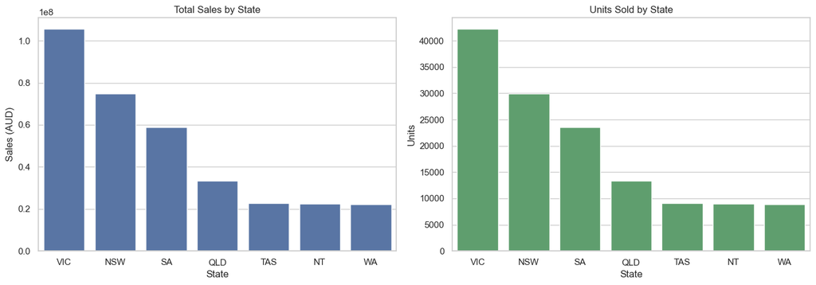

```
Top 3 states by revenue:
 State
VIC    105565000
NSW     74970000
SA      58857500
Name: Sales, dtype: int64

Bottom 3 states by revenue:
 State
TAS    22760000
NT     22580000
WA     22152500
Name: Sales, dtype: int64
```

```python
state_sales = df.groupby('State')['Sales'].sum().sort_values(ascending=False)
state_units = df.groupby('State')['Unit'].sum().loc[state_sales.index]

fig, ax = plt.subplots(1, 2, figsize=(14,5))
sns.barplot(x=state_sales.index, y=state_sales.values, ax=ax[0])
ax[0].set_title('Total Sales by State')
ax[0].set_ylabel('Sales (AUD)')
ax[0].set_xlabel('State')

sns.barplot(x=state_units.index, y=state_units.values, ax=ax[1], color=sns.color_palette()[2])
ax[1].set_title('Units Sold by State')
ax[1].set_ylabel('Units')
ax[1].set_xlabel('State')
plt.tight_layout()
plt.show()

print("Top 3 states by revenue:\n", state_sales.head(3))
print("\nBottom 3 states by revenue:\n", state_sales.tail(3))
```

#### Question: Group-wise sales across states

Covers: 'State-wise sales analysis for different demographic groups (Kids, Women, Men, Seniors).'

### Q6: Group-wise Sales Across States

### Demographic Group Performance by State

Pivot to see which customer groups contribute most in each state.

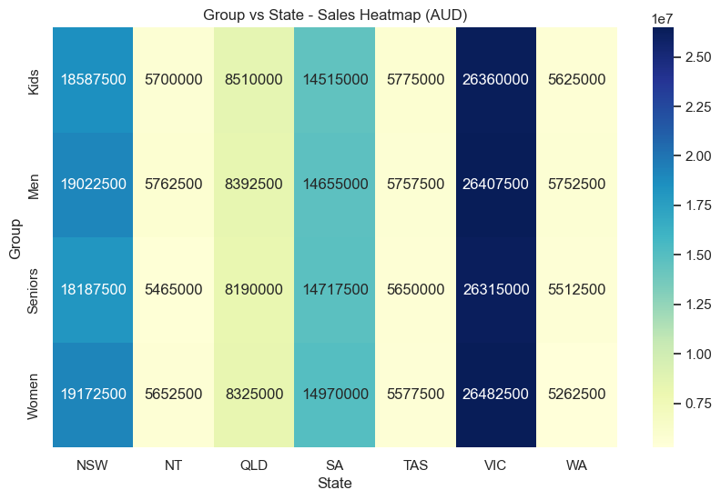

```python
pivot_group_state = df.pivot_table(values='Sales', index='Group', columns='State', aggfunc='sum')
plt.figure(figsize=(10,6))
sns.heatmap(pivot_group_state, cmap='YlGnBu', annot=True, fmt='.0f')
plt.title('Group vs State - Sales Heatmap (AUD)')
plt.show()
```

#### Question: Time-of-day peak/off-peak analysis

Covers: 'Time-of-the-day analysis to identify peak and off-peak sales periods.'

### Q7: Time-of-Day Peak/Off-Peak

### Time-of-Day Analysis

Identify peak and off-peak windows to support targeting and staffing.

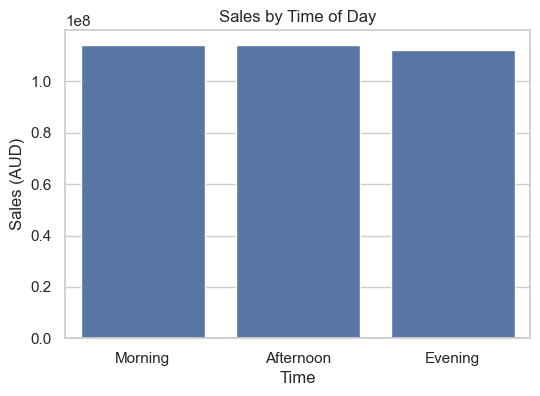

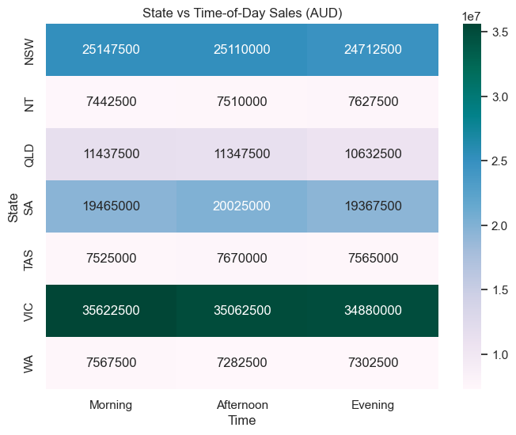

```python
time_sales = df.groupby('Time')['Sales'].sum().reindex(TIME_ORDER)
plt.figure(figsize=(6,4))
sns.barplot(x=time_sales.index, y=time_sales.values)
plt.title('Sales by Time of Day')
plt.ylabel('Sales (AUD)')
plt.show()

state_time = df.pivot_table(values='Sales', index='State', columns='Time', aggfunc='sum').reindex(columns=TIME_ORDER)
plt.figure(figsize=(8,6))
sns.heatmap(state_time, cmap='PuBuGn', annot=True, fmt='.0f')
plt.title('State vs Time-of-Day Sales (AUD)')
plt.show()
```

#### Question: Daily/Weekly/Monthly/Quarterly charts

Covers: 'The dashboard must contain daily, weekly, monthly, and quarterly charts.'

### Q8: Daily/Weekly/Monthly/Quarterly Charts

### Time Series Views (Daily, Weekly, Monthly, Quarterly)

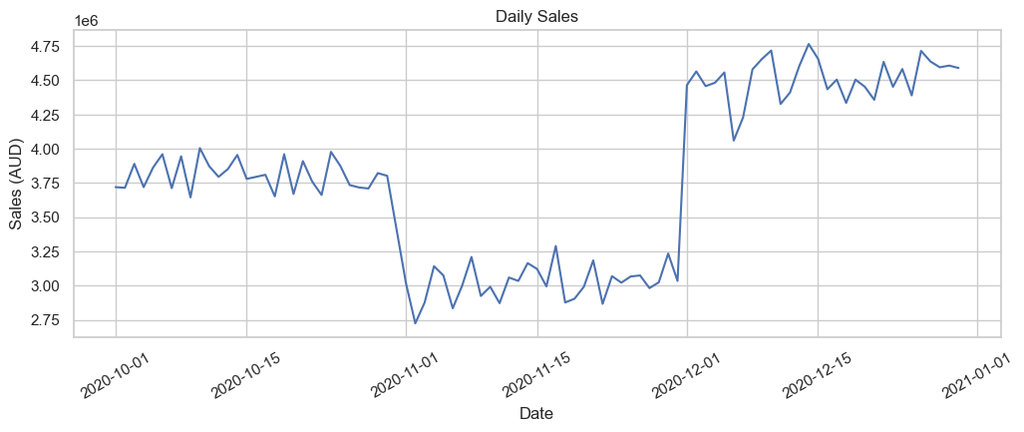

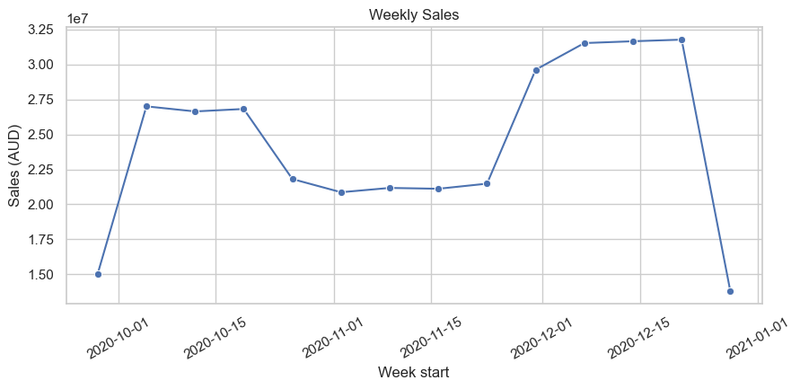

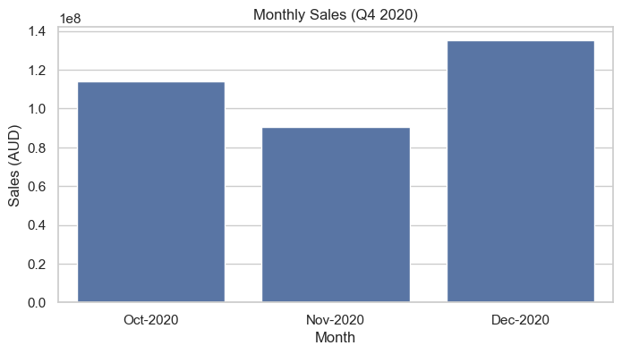

[figure not shown]

```python
# Daily
plt.figure(figsize=(12,4))
daily = df.groupby('Date')['Sales'].sum().sort_index()
sns.lineplot(x=daily.index, y=daily.values)
plt.title('Daily Sales')
plt.ylabel('Sales (AUD)')
plt.xlabel('Date')
plt.xticks(rotation=30)
plt.show()

# Weekly (Monday-start because of pandas default)
weekly = df.groupby('Week')['Sales'].sum().sort_index()
plt.figure(figsize=(10,4))
sns.lineplot(x=weekly.index, y=weekly.values, marker='o')
plt.title('Weekly Sales')
plt.ylabel('Sales (AUD)')
plt.xlabel('Week start')
plt.xticks(rotation=30)
plt.show()

# Monthly
monthly = df.groupby('Month')['Sales'].sum().sort_index()
plt.figure(figsize=(8,4))
sns.barplot(x=monthly.index.strftime('%b-%Y'), y=monthly.values)
plt.title('Monthly Sales (Q4 2020)')
plt.ylabel('Sales (AUD)')
plt.xlabel('Month')
plt.show()

# Quarterly
quarterly = df.groupby('Quarter')['Sales'].sum().sort_index()
plt.figure(figsize=(6,4))
sns.barplot(x=quarterly.index.strftime('Q%q %Y'), y=quarterly.values, color=sns.color_palette()[4])
plt.title('Quarterly Sales')
plt.ylabel('Sales (AUD)')
plt.xlabel('Quarter')
plt.show()
```

#### Question: Box plot for descriptive statistics

Covers: 'Use a box plot for descriptive statistics.'

### Q9: Box Plot for Descriptive Statistics

### Descriptive Statistics (Box Plot)

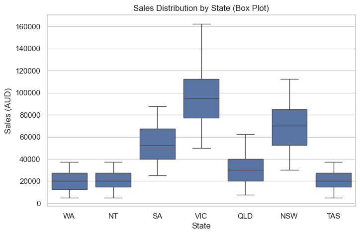

```
        Sales
count   7,560
mean   45,014
std    32,254
min     5,000
25%    20,000
50%    35,000
75%    65,000
max   162,500
```

```python
plt.figure(figsize=(8,5))
sns.boxplot(data=df, x='State', y='Sales')
plt.title('Sales Distribution by State (Box Plot)')
plt.ylabel('Sales (AUD)')
plt.show()

print(df[['Sales']].describe())
```

#### Question: Seaborn distribution plot

Covers: 'Use the Seaborn distribution plot for statistical plotting.'

### Q10: Seaborn Distribution Plot

### Sales Distribution (Seaborn Distribution Plot)

Shows the overall spread of individual transaction sales values.

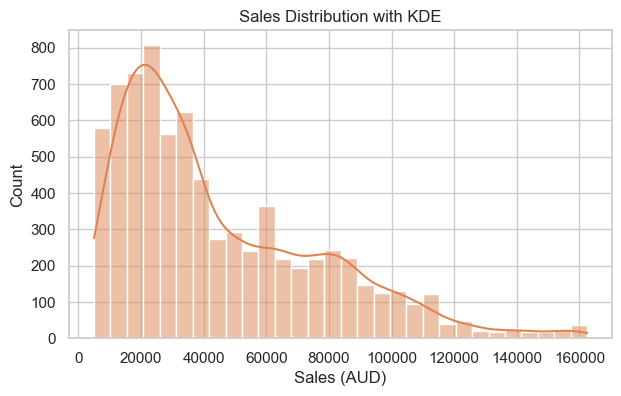

```python
plt.figure(figsize=(7,4))
sns.histplot(df['Sales'], kde=True, bins=30, color=sns.color_palette()[1])
plt.title('Sales Distribution with KDE')
plt.xlabel('Sales (AUD)')
plt.show()
```

## Submission Write-up (Summary)

- **Goal:** Analyze Q4 2020 Australia apparel sales to guide Sales & Marketing on where to invest, which demographics to target, and when to run offers.
- **Data:** `AusApparalSales4thQrt2020.csv` (7,560 rows; fields: Date, Time, State, Group, Unit, Sales). No missing/negative values.
- **Method:** Cleaned whitespace; parsed dates; engineered Month/Week/Quarter; min-max normalized Unit & Sales; GroupBy aggregations; visualized with Seaborn/Matplotlib (state revenue & units, group heatmap, time-of-day bars/heatmap, daily/weekly/monthly/quarterly trends, box plot, distribution).
- **Key findings:**
  - Top revenue states: VIC, NSW, SA; lowest: WA, NT, TAS.
  - Time-of-day: Morning/Afternoon slightly lead; Evening close behind.
  - Demographics: All groups contribute similarly; VIC dominates every group.
- **Recommendations:**
  - Double down on VIC/NSW high-value segments; premium/loyalty offers.
  - Target WA/NT/TAS with localized promos and assortments tuned to their leading group (see heatmap).
  - Staff/ads heavier in Morning/Afternoon; use off-peak for loyalty nudges.
  - Maintain monthly dashboards; monitor weekly for campaign effects.
- **Tools & libs:** Python 3.9, pandas, seaborn, matplotlib, scikit-learn (MinMaxScaler), nbconvert.

## Findings & Recommendations

- **Top revenue states**: Use the bar chart to confirm leaders; focus retention and premium offers there.
- **Low revenue states**: Bottom states warrant localized promos, influencer tie-ups, or inventory refresh. Consider pilot campaigns tailored to the dominant demographic group in each low-performing state (see heatmap).
- **Peak times**: Highest volumes occur where the time-of-day bars peak; staff and ads should concentrate here. Off-peak windows are good for loyalty nudges.
- **Demographics**: Heatmap shows which groups drive each state; align assortments and messaging accordingly.
- **Visualization choice**: Seaborn is used for concise statistical plots (distribution, boxplot) and consistent styling; Matplotlib is leveraged underneath for flexibility in axes formatting.